# Perry Meeting May 16 2022

Danny Foster

5/11/2022

# Intro

In an attempt to address some of the wonkyness in the first two suites of IPMs, I also have constructed versions of each with the individual size range limited to the 95th percentile of observed sizes. Last, there are versions of each suite (the observed plots with median parameter values, and the idealized plots with the full posterior) with a restricted size distribution and using the midpoint rule (rather than the mean rule) for individual sizes.

Analysis of the IPMs follows the SI for Merow et al. MEE 2014 “Advancing population ecology with integral projection models: a practical guide” to extract population asymptotic growth rates, stable size distributions, reproductive values, and sensitivity and elasticity matrices.

## Questions for Perry

- Seen similar results from other work with IPMs? Would be helpful to diagnose the source of the wonky looking results, and debug if necessary.
- How much should infrequent weird behavior (e.g. negative reproductive values for 5% of sizeclass:plot combinations) make me distrust the central tendencies (ie the median behavior looks fine)?
- How much should the wonky results viz. reproductive value, elasticitiy, etc. make me distrust the results for the asymptotic population growth rate, which look fine?
- Advice for how to move forward with a paper?
  - Full size class distribution vs. restricted
  - Bin resolution and midpoint vs mean
  - Abandon the additional analyses (probably means changing target journal)?
  - Keep IPM setup consistent between parameter-estimation and results?

# Real plots, full size range

IPMs built with the observed plot data, posterior median parameter values for the vital rate functions, and the full size range.

## Build transition matrices

Using posterior median parameter values and the full size range:

```r
library(here)
library(tidyverse)
library(posterior)
library(bayesplot)

knitr::opts_chunk$set(message = FALSE)

#ncores <- 12
#registerDoParallel(ncores)
```

Extract parameter values from posterior:

```r
# load mcmc results
posterior = readRDS(here::here('02-data',
                               '03-results',
                               'real_fits',
                               'posterior_draws.rds'))

# extract parameters
beta_s =
  posterior %>%
  select(contains('beta_s')) %>%
  summarise_all(median) %>%
  as.data.frame() %>%
  as.numeric()

beta_g =
  posterior %>%
  select(contains('beta_g')) %>%
  summarise_all(median) %>%
  as.data.frame() %>%
  as.numeric()

beta_f =
  posterior %>%
  select(contains('beta_f')) %>%
  summarise_all(median) %>%
  as.data.frame() %>%
  as.numeric()

plotEffect_s =
  posterior %>%
  select(contains('plotEffect_s')) %>%
  summarise_all(median) %>%
  as.data.frame() %>%
  as.numeric()

plotEffect_g =
  posterior %>%
  select(contains('plotEffect_g')) %>%
  summarise_all(median) %>%
  as.data.frame() %>%
  as.numeric()

plotEffect_f =
  posterior %>%
  select(contains('plotEffect_f')) %>%
  summarise_all(median) %>%
  as.data.frame() %>%
  as.numeric()

ecoEffect_s =
  posterior %>%
  select(contains('ecoEffect_s')) %>%
  summarise_all(median) %>%
  as.data.frame() %>%
  as.numeric()

ecoEffect_g =
  posterior %>%
  select(contains('ecoEffect_g')) %>%
  summarise_all(median) %>%
  as.data.frame() %>%
  as.numeric()

ecoEffect_f =
  posterior %>%
  select(contains('ecoEffect_f')) %>%
  summarise_all(median) %>%
  as.data.frame() %>%
  as.numeric()

sigmaEpsilon_g =
  posterior %>%
  summarise_all(median) %>%
  pull(sigmaEpsilon_g) %>%
  as.numeric()
```

Load the size class data, which gives the upper and lower bounds, midpoint, and mean size in each of 20 individual size bins. Size is the diameter at breast height (DBH), with a range of 0 - 2.54 m broken into bins which are 0.127m wide.

```r
size_metadata =
  readRDS(here::here('02-data',
                     '01-preprocessed',
                     'size_metadata.rds')) %>%
  # convert to metric
  mutate(bin_midpoint = bin_midpoint * 0.0254,
         bin_lower = bin_lower * 0.0254,
         bin_upper = bin_upper * 0.0254,
         dbh_m.mean = dbh_in.mean * 0.0254)

size_metadata$r =
  c(readRDS(here::here('02-data',
                       '02-for_analysis',
                       'pila_training.rds'))$r,
    rep(0, times = 18))
```

Here’s a histogram of the size of individuals that were used for the survival submodel. It looks weird because of the nested plot design, with different sampling areas for different sizes of trees. The largest individual in the data is 2.46m DBH, but the 99th percentile is only 1.51m DBH and the 95th percentile is only 1.24m DBH. This will become important later.

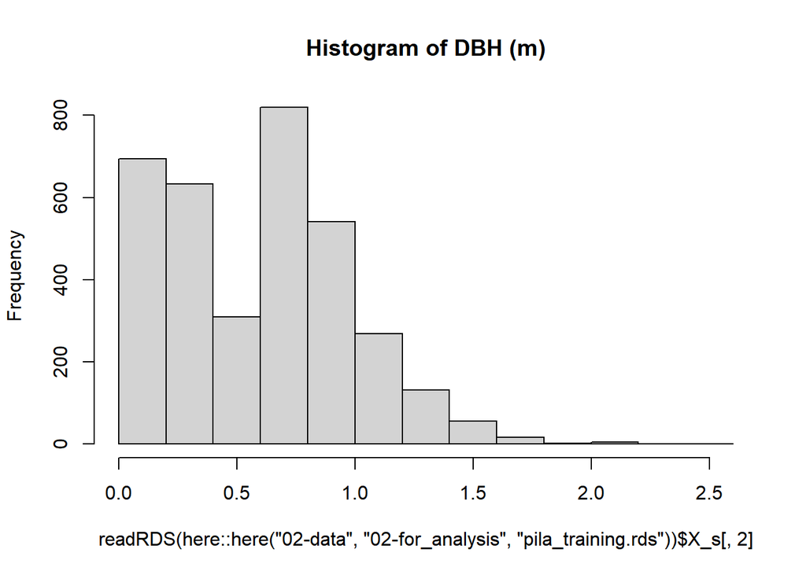

```r
hist(readRDS(here::here('02-data','02-for_analysis', 'pila_training.rds'))$X_s[,2],
     main = 'Histogram of DBH (m)')
```

Load the plots data, which includes other data used for fixed and random effects in the vital rate functions:

```r
plots =
  readRDS(here::here('02-data', '01-preprocessed', 'plot_data.rds'))%>%
  mutate(ba_scaled = as.numeric(scale(ba_ft2ac)),
         cwd_dep90_scaled = as.numeric(scale(cwd_departure90)),
         cwd_mean_scaled = as.numeric(scale(cwd_mean)),
         intercept = 1) %>%
  select(plot_id, lat, lon, ecosubcd, intercept, fire, wpbr, ba_scaled,
         cwd_dep90_scaled,cwd_mean_scaled)

plots.pila =
  plots %>%
  right_join(
    readRDS(here::here('02-data', '02-for_analysis', 'union_plots.rds'))
  ) %>%
  right_join(
    readRDS(here::here('02-data', '02-for_analysis', 'union_ecosubs.rds'))
  )
```

```r
A_median_full =
    array(dim = list(nrow(size_metadata),
                     nrow(size_metadata),
                     nrow(plots.pila)),
          dimnames = list('class_to' = 1:nrow(size_metadata),
                          'class_from' = 1:nrow(size_metadata),
                          'plot' = 1:nrow(plots.pila)),
          data =
            sapply(X = 1:nrow(plots.pila),
                   FUN = function(plot){

                     # construct explanatory variable matrix for vital rate
                     # functions for the current plot
                     X =
                       plots.pila %>%
                       slice(plot) %>%
                       expand(nesting(intercept, fire, wpbr, ba_scaled,
                                      cwd_dep90_scaled,cwd_mean_scaled),
                              dbh = size_metadata$dbh_m.mean) %>%
                       mutate(dbh_fire = dbh*fire,
                              dbh_wpbr = dbh*wpbr,
                              dbh_ba = dbh*ba_scaled,
                              dbh_cwd_dep90 = dbh*cwd_dep90_scaled,
                              dbh_cwd_mean = dbh*cwd_mean_scaled) %>%
                       select(intercept, dbh, fire, wpbr, ba_scaled,
                              cwd_dep90_scaled, cwd_mean_scaled,
                              dbh_fire, dbh_wpbr, dbh_ba,
                              dbh_cwd_dep90, dbh_cwd_mean) %>%
                       as.matrix()

                     # calculate vector of survival probabilities for each
                     # size class on this plot with this parameter draw
                     p =
                       boot::inv.logit(as.numeric(X %*% beta_s) +
                                         ecoEffect_s[plots.pila$ecosub.i[plot]]+
                                         plotEffect_s[plots.pila$plot_id.i][plot])

                     # calculate vector of mean size at time 2 for each size
                     # class on this plot with this parameter draw
                     mu = as.numeric(X %*% beta_g)+
                       ecoEffect_g[plots.pila$ecosub.i[plot]]+
                       plotEffect_g[plots.pila$plot_id.i[plot]]

                     # calculate vector of fecundity for each size class on this
                     # plot with this parameter draw
                     f =
                       exp(as.numeric(X %*% beta_f)+
                             ecoEffect_f[plots.pila$ecosub.i[plot]]+
                             plotEffect_f[plots.pila$plot_id.i[plot]])

                     # loop over each "from" size class
                     sapply(X = 1:nrow(size_metadata),
                            FUN = function(class_from){

                              # growth kernel from this size class into
                              # each other size class, using the cumulative
                              # density function as recommended by Doak et al. 2021
                              g =
                                ((pnorm(size_metadata$bin_upper,
                                        mu[class_from],
                                        sigmaEpsilon_g) -
                                    pnorm(size_metadata$bin_lower,
                                          mu[class_from],
                                          sigmaEpsilon_g))/
                                   (1-pnorm(0,
                                            mu[class_from],
                                            sigmaEpsilon_g)))

                              # loop over every destination size class
                              sapply(X = 1:nrow(size_metadata),
                                     FUN = function(class_to){

                                       # for testing, just to make sure
                                       # I've constructed the array correctly
                                       #paste0('to:',class_to,',from:',class_from,
                                       #       ',plot:',plot)

                                       # calculate the transition kernel
                                       # between the current "from" class and
                                       # the current "to" class
                                       transition_kern =
                                         # survival of each from class
                                         (p[class_from] *
                                            # prob of growth from to
                                            g[class_to]) +
                                         # number of new recruits in this "to"
                                         # class is the fecundity of the "from"
                                         # class times the recruitment size
                                         # kernel for this "to" class
                                         (f[class_from] *
                                            size_metadata$r[class_to])
                                       return(transition_kern)

                                     })

                            })

                   }))

# save this so we don't have to rebuild it every time we knit
saveRDS(A_median_full,
        here::here('02-data',
                   '03-results',
                   'real_fits',
                   'A_median_full.rds'))
```

```r
A_median_full =
  readRDS(here::here('02-data',
                     '03-results',
                     'real_fits',
                     'A_median_full.rds'))
```

## Asymptotic population growth rate

```r
lambda_full =
  sapply(X = 1:nrow(plots.pila),
         FUN = function(plot){
           A_plot = A_median_full[,,plot]
           lambda_plot = max(as.numeric(Re(eigen(A_plot)$values)))
           return(lambda_plot)
         })
```

The distribution of lambda across all plots, using the posterior median parameter values for the vital rate functions, is figure 7 in the paper (after being truncated to the range 0-2.5 for clarity). I was ignoring the long right tail, which is maybe a mistake?

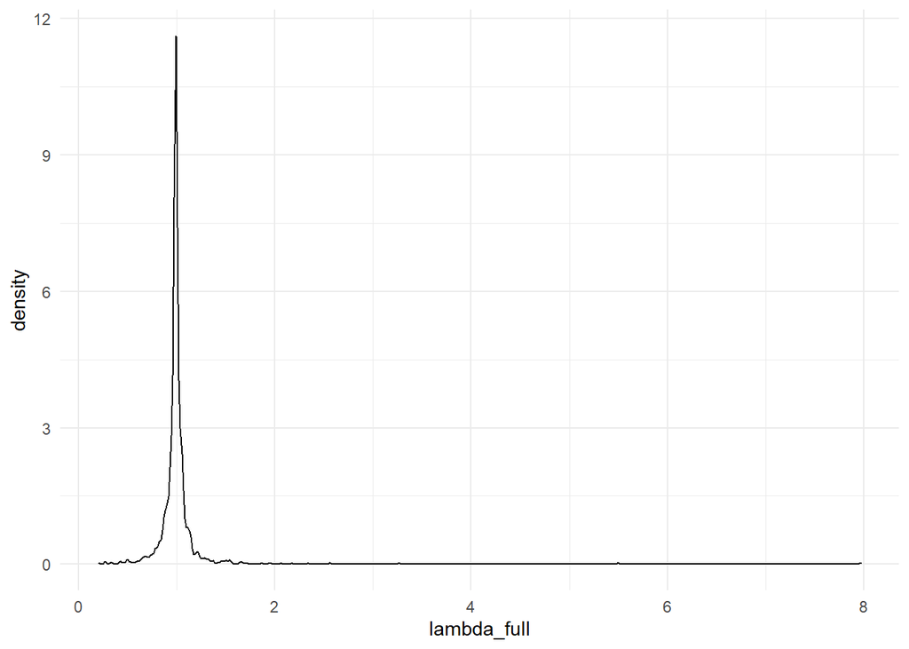

```r
ggplot(data.frame(lambda_full),
       aes(x = lambda_full))+
  geom_density()+
  theme_minimal()
```

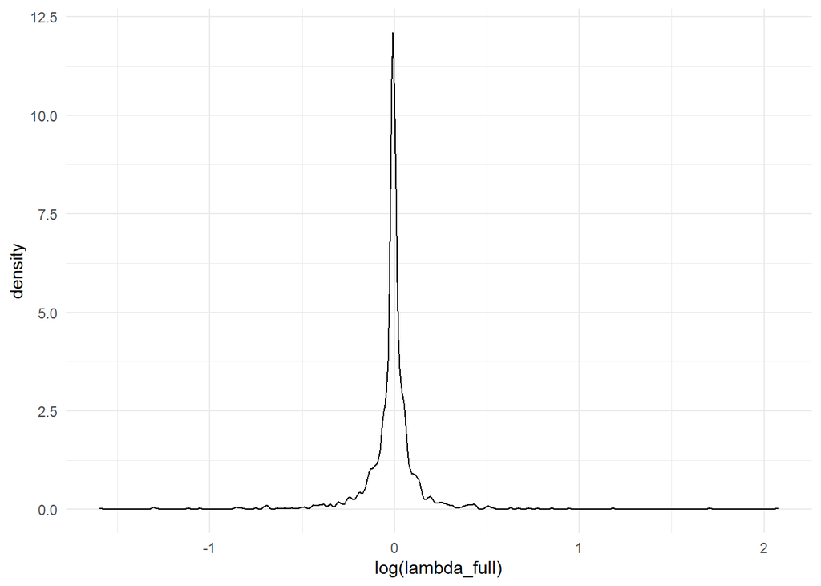

```r
ggplot(data.frame(lambda_full),
       aes(x = log(lambda_full)))+
  geom_density()+
  theme_minimal()
```

Proportion of plots where lambda < 1:

```r
# proportion of plots where lambda < 1
length(lambda_full[lambda_full<1])/length(lambda_full)
```

```
## [1] 0.6433757
```

```r
quantile(lambda_full, c(0.05, 0.1, 0.25, 0.5, 0.75, 0.9, 0.95))
```

```
##        5%       10%       25%       50%       75%       90%       95%
## 0.7939077 0.8769178 0.9611793 0.9920781 1.0224072 1.0968380 1.1942972
```

## Stable size distribution

```r
# stable size distribution
ssd_full =
  matrix(nrow = nrow(size_metadata),
         ncol = nrow(plots.pila),
         byrow = FALSE,
         data =
           sapply(X = 1:nrow(plots.pila),
                  FUN = function(plot){
                    A.plot = A_median_full[,,plot]
                    # from supplamentory materials for merow et al 2014
                    # "On using integral projection models..."
                    w.eigen = Re(eigen(A.plot)$vectors[,1])
                    ssd = w.eigen / sum(w.eigen)
                    return(ssd)
                  }))

ssd_full.df =
  expand.grid('plot' = 1:nrow(plots.pila),
              'sizeclass' = 1:nrow(size_metadata)) %>%
  left_join(size_metadata %>%
              mutate(bin_midpoint_cm = bin_midpoint*100) %>%
              select(sizeclass = bin_id, bin_midpoint_cm))

ssd_full.df$class_proportion =

  as.numeric(
    sapply(X = 1:nrow(size_metadata),
           FUN = function(sizeclass){

             return(ssd_full[sizeclass,])

           })
  )
```

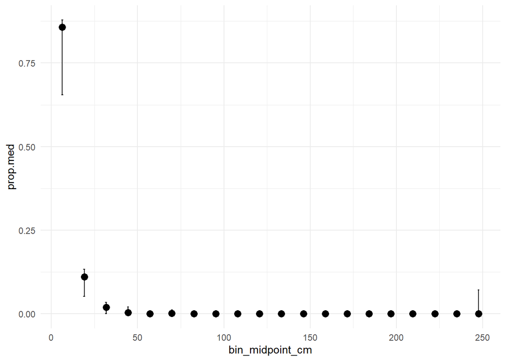

```r
# stable size distribution is inverse J not surprising
ssd_full.df %>%
  group_by(bin_midpoint_cm, sizeclass) %>%
  summarise(prop.med = median(class_proportion),
            prop.05 = quantile(class_proportion, 0.05),
            prop.95 = quantile(class_proportion, 0.95)) %>%
  ungroup() %>%
  ggplot(aes(x = bin_midpoint_cm))+
  geom_point(aes(y = prop.med), size = 3)+
  geom_errorbar(aes(ymin = prop.05, ymax = prop.95),
                width = 1)+
  theme_minimal()
```

The stable size distribution shows a ton of individuals in the smallest size classes. This is totally what you expect for long-live tree species. Points are the median proportion in the sizeclass across all plots, and error bars are the 5th and 95th percentile proportion in each sizeclass (across all plots).

Log scaled y axis for clarity:

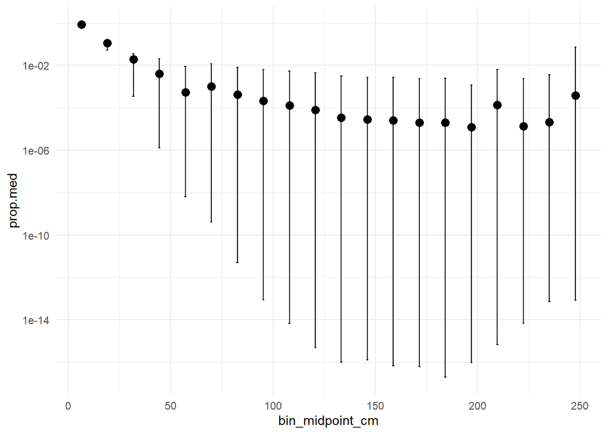

```r
# stable size distribution is inverse J not surprising
ssd_full.df %>%
  group_by(bin_midpoint_cm, sizeclass) %>%
  summarise(prop.med = median(class_proportion),
            prop.05 = quantile(class_proportion, 0.05),
            prop.95 = quantile(class_proportion, 0.95)) %>%
  ungroup() %>%
  ggplot(aes(x = bin_midpoint_cm))+
  geom_point(aes(y = prop.med), size = 3)+
  geom_errorbar(aes(ymin = prop.05, ymax = prop.95),
                width = 1)+
  theme_minimal()+
  scale_y_log10()
```

Wigglyness is caused by jitter in the mean size for each bin; better to use midpoints?

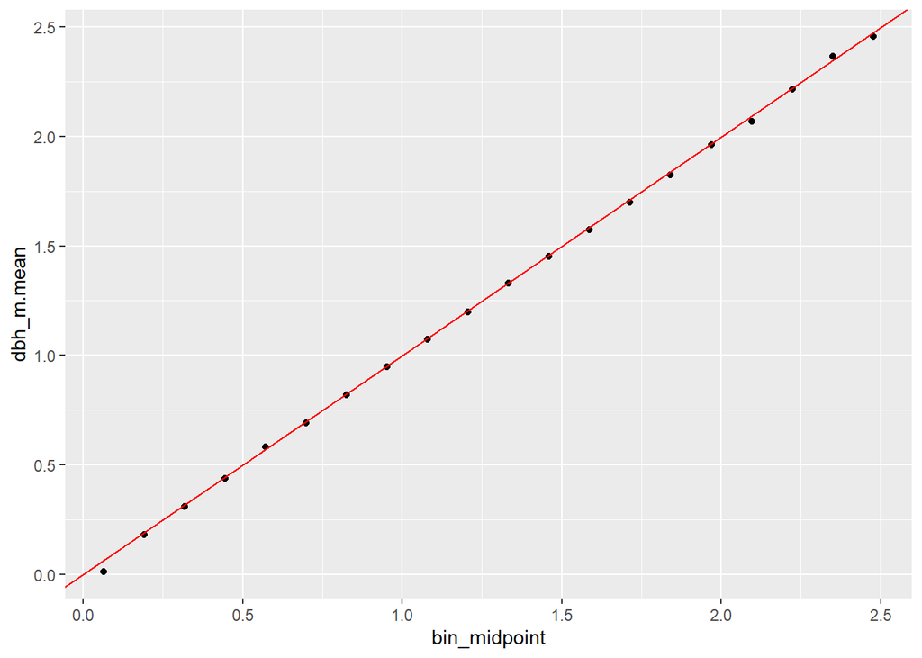

```r
ggplot(size_metadata,
       aes(x = bin_midpoint, y = dbh_m.mean))+
  geom_point()+
  geom_abline(intercept = 0, slope = 1, color = 'red')
```

## Reproductive value

```r
plot_repro.full =
  matrix(nrow = nrow(size_metadata),
         ncol = nrow(plots.pila),
         byrow = FALSE,
         data =
           sapply(X = 1:nrow(plots.pila),
                  FUN = function(plot){
                    A.plot = A_median_full[,,plot]
                    # from supplementary materials for merow et al 2014
                    # "On using integral projection models..."
                    v.eigen = Re(eigen(t(A.plot))$vectors[,1])
                    rv = v.eigen / v.eigen[1]
                    return(rv)
                  }))


plot_repro_full.df =
  expand.grid('plot' = 1:nrow(plots.pila),
              'sizeclass' = 1:nrow(size_metadata)) %>%
  left_join(size_metadata %>%
              mutate(bin_midpoint_cm = bin_midpoint*100) %>%
              select(sizeclass = bin_id, bin_midpoint_cm))

plot_repro_full.df$reproductive_value =

  as.numeric(
    sapply(X = 1:nrow(size_metadata),
           FUN = function(sizeclass){

             return(plot_repro.full[sizeclass,])

           })
  )
```

Here’s where things start getting really wonky; there are plot:sizeclass combinations with a negative reproductive value?

```r
plot_repro_full.df  %>% summary()
```

```
##       plot          sizeclass     bin_midpoint_cm  reproductive_value
##  Min.   :   1.0   Min.   : 1.00   Min.   :  6.35   Min.   :    -Inf
##  1st Qu.: 276.0   1st Qu.: 5.75   1st Qu.: 66.67   1st Qu.:   41.41
##  Median : 551.5   Median :10.50   Median :127.00   Median : 1035.74
##  Mean   : 551.5   Mean   :10.50   Mean   :127.00   Mean   :     NaN
##  3rd Qu.: 827.0   3rd Qu.:15.25   3rd Qu.:187.32   3rd Qu.:40288.95
##  Max.   :1102.0   Max.   :20.00   Max.   :247.65   Max.   :     Inf
##                                                    NA's   :3
```

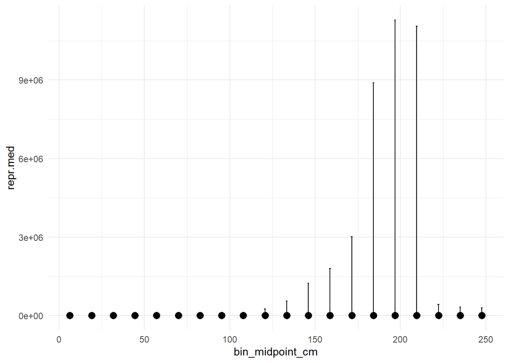

```r
plot_repro_full.df %>%

  group_by(bin_midpoint_cm, sizeclass) %>%

  # there's a couple of NA plots for reproductive value, looks like cases
  # where numerical errors are resulting in a divide by zero when going from
  # v.eigen to reproductive value?
  summarise(repr.med = median(reproductive_value, na.rm = TRUE),

            # there's a couple of NAs in h
            repr.05 = quantile(reproductive_value, 0.25, na.rm = TRUE),
            repr.95 = quantile(reproductive_value, 0.75, na.rm = TRUE)) %>%
  ungroup() %>%
  ggplot(aes(x = bin_midpoint_cm))+
  geom_point(aes(y = repr.med), size = 3)+
  geom_errorbar(aes(ymin = repr.05, ymax = repr.95),
                width = 1)+
  theme_minimal()
```

```r
plot_repro_full.df %>%
  filter(reproductive_value < 0) %>%
  head()
```

```
##   plot sizeclass bin_midpoint_cm reproductive_value
## 1   17         2           19.05          -3.784925
## 2   18         2           19.05        -320.000000
## 3   31         2           19.05          -6.802139
## 4   49         2           19.05         -13.693023
## 5  105         2           19.05          -8.580442
## 6  113         2           19.05         -11.130435
```

I suspect this is some sort of overflow problem, it becomes much less severe if we don’t use the larger size bins.

## Sensitivity and elasticity

```r
# sensitivity and elasticity
v.dot.w_plot_full =

  sapply(X = 1:nrow(plots.pila),
         FUN = function(plot){
           sum(ssd_full[,plot] * plot_repro.full[,plot])*0.127
         })

sens_plot_full =
  array(dim = list(nrow(size_metadata),
                   nrow(size_metadata),
                   nrow(plots.pila)),
        dimnames =
          list('size_to' = 1:nrow(size_metadata),
               'size_from' = 1:nrow(size_metadata),
               'plot' = 1:nrow(plots.pila)),
        data =
          sapply(X = 1:nrow(plots.pila),
                 FUN = function(plot){
                   outer(plot_repro.full[,plot], ssd_full[,plot])/
                     v.dot.w_plot_full[plot]
                 }))


elas_plot_full =

  array(dim = list(nrow(size_metadata),
                   nrow(size_metadata),
                   nrow(plots.pila)),
        dimnames =
          list('size_to' = 1:nrow(size_metadata),
               'size_from' = 1:nrow(size_metadata),
               'plot' = 1:nrow(plots.pila)),
        data =
          sapply(X = 1:nrow(plots.pila),
                 FUN = function(plot){
                   matrix(as.vector(sens_plot_full[,,plot])*
                            as.vector(A_median_full[,,plot])/
                            lambda_full[plot])
                 }))
```

Following the merow code, and looking at a single plot I get this:

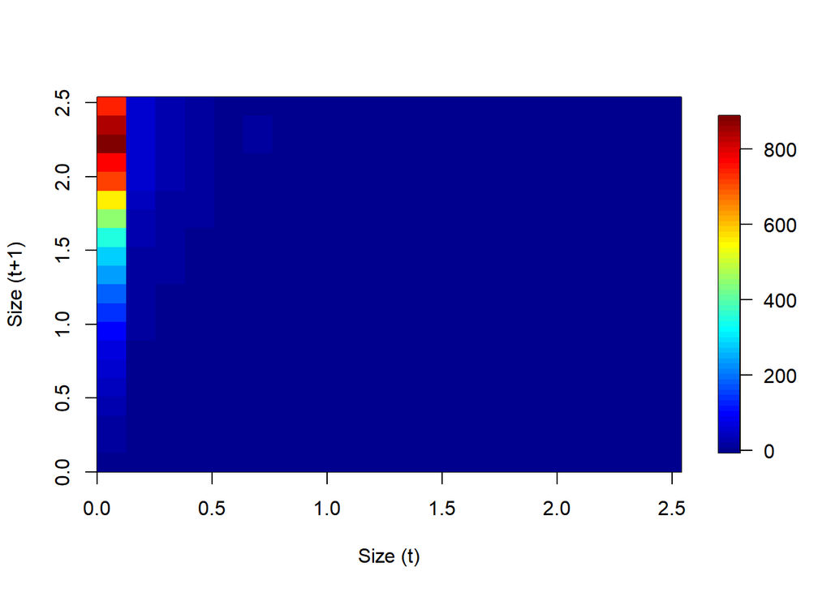

```r
# looks like its transitions from the biggest classes into the smallest classes
# that matter most; edit: well now I'm confused, was I swapping the rows and
# columns before or am I swapping them now? this doesn't look biologically
# reasonable, but it does match the demo sensitivity in the merow paper
# where its from the small class into the big class that has the highest
# sensitivity, now I'm wondering if the merow code has a bug?
fields::image.plot(size_metadata$bin_midpoint,
                   size_metadata$bin_midpoint,
                   t(sens_plot_full[,,4]),
                   xlab = 'Size (t)', ylab = 'Size (t+1)')
```

Which looks weird, because its flaggin the biologically-impossible transition from the smallest size class into the largest as the most important? I thought I might have transposed a matrix somewhere, but this does look like the sensitivity matrix shown in figure 1.3 of the SI, except that my high values are **much** higher. Is sensitivity just not that useful, which is why people use elasticity?

I see the same behavior when plotting the median sensitivity value across all plots:

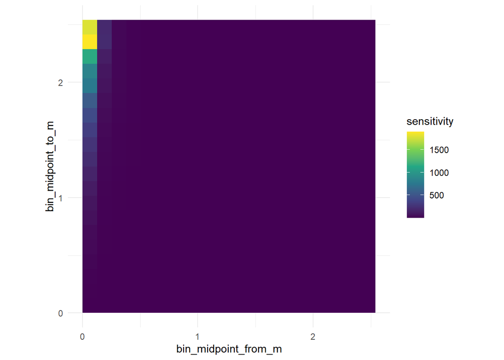

```r
sens_elas_plot_full.df =
  expand.grid(size_to = size_metadata$bin_id,
              size_from = size_metadata$bin_id) %>%
  left_join(size_metadata %>%
              select(size_to = bin_id,
                     bin_midpoint_to_m = bin_midpoint)) %>%
  left_join(size_metadata %>%
              select(size_from = bin_id,
                     bin_midpoint_from_m = bin_midpoint)) %>%
  expand(nesting(size_to, size_from, bin_midpoint_to_m, bin_midpoint_from_m),
         plot = 1:nrow(plots.pila)) %>%

  arrange(plot, size_to, size_from)

sens_elas_plot_full.df$sensitivity =

  sapply(X = 1:nrow(plots.pila),
         FUN = function(plot){

           sapply(X = 1:nrow(size_metadata),
                  FUN = function(size_to){

                    sapply(X = 1:nrow(size_metadata),
                           FUN = function(size_from){

                             sens_plot_full[size_to, size_from, plot]

                           })

                  })

         }) %>%
  as.vector()


sens_elas_plot_full.df %>%
  group_by(size_to, size_from, bin_midpoint_to_m, bin_midpoint_from_m) %>%
  summarise(sensitivity = median(sensitivity, na.rm = TRUE)) %>%
  ungroup() %>%
  ggplot(aes(x = bin_midpoint_from_m,
           y = bin_midpoint_to_m,
           fill = sensitivity))+
  geom_tile()+
  coord_fixed()+
  theme_minimal()+
  scale_fill_viridis_c()
```

Are these really high values normal, or something to be concerned about?

```r
summary(sens_elas_plot_full.df)
```

```
##     size_to        size_from     bin_midpoint_to_m bin_midpoint_from_m
##  Min.   : 1.00   Min.   : 1.00   Min.   :0.0635    Min.   :0.0635
##  1st Qu.: 5.75   1st Qu.: 5.75   1st Qu.:0.6667    1st Qu.:0.6667
##  Median :10.50   Median :10.50   Median :1.2700    Median :1.2700
##  Mean   :10.50   Mean   :10.50   Mean   :1.2700    Mean   :1.2700
##  3rd Qu.:15.25   3rd Qu.:15.25   3rd Qu.:1.8733    3rd Qu.:1.8733
##  Max.   :20.00   Max.   :20.00   Max.   :2.4765    Max.   :2.4765
##
##       plot         sensitivity
##  Min.   :   1.0   Min.   :      0
##  1st Qu.: 276.0   1st Qu.:      0
##  Median : 551.5   Median :      0
##  Mean   : 551.5   Mean   :    302
##  3rd Qu.: 827.0   3rd Qu.:      1
##  Max.   :1102.0   Max.   :4115574
##                   NA's   :800
```

I have NAs in the sensitivity matrices, all from 2 plots:

```r
sens_elas_plot_full.df %>%
  filter(is.na(sensitivity)) %>%
  pull(plot) %>%
  unique()
```

```
## [1] 571 669
```

There’s not anything obviously weird about the transition matrices for these two plots:

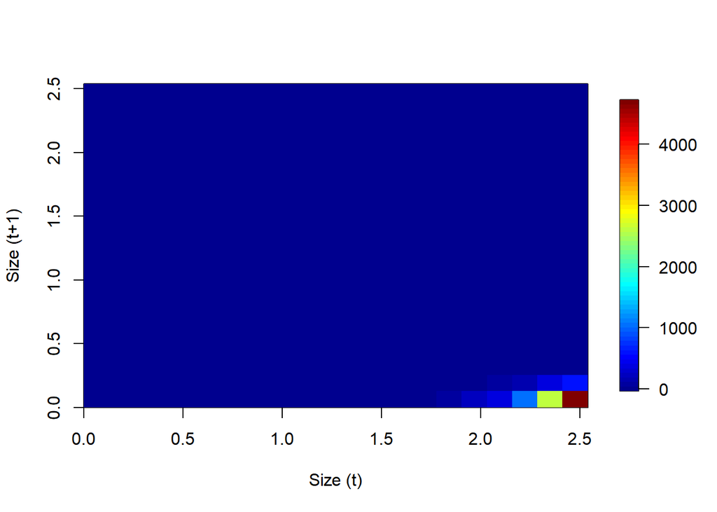

```r
fields::image.plot(size_metadata$bin_midpoint,
                   size_metadata$bin_midpoint,
                   t(A_median_full[,,571]),
                   xlab = 'Size (t)', ylab = 'Size (t+1)')
```

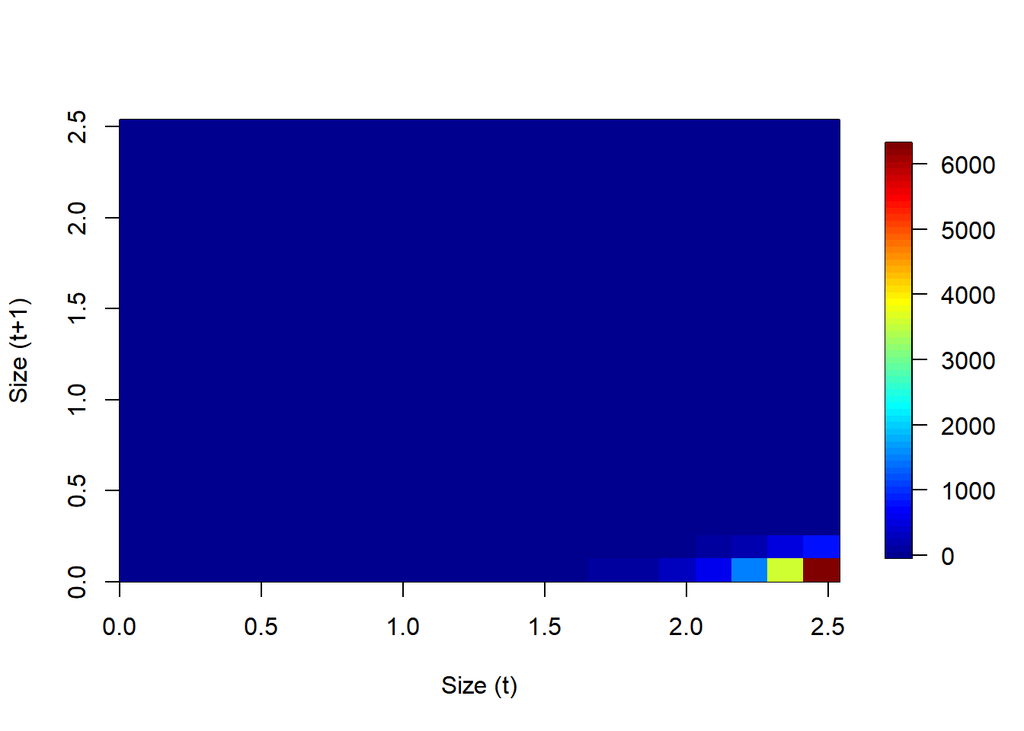

```r
fields::image.plot(size_metadata$bin_midpoint,
                   size_metadata$bin_midpoint,
                   t(A_median_full[,,669]),
                   xlab = 'Size (t)', ylab = 'Size (t+1)')
```

Transition matrix really emphasizes how much influence that log link on the fecundity function has though.

```r
sens_elas_plot_full.df$elasticity =

  sapply(X = 1:nrow(plots.pila),
         FUN = function(plot){

           sapply(X = 1:nrow(size_metadata),
                  FUN = function(size_to){

                    sapply(X = 1:nrow(size_metadata),
                           FUN = function(size_from){

                             elas_plot_full[size_to, size_from, plot]

                           })

                  })

         }) %>%
  as.vector()
```

```r
summary(sens_elas_plot_full.df)
```

```
##     size_to        size_from     bin_midpoint_to_m bin_midpoint_from_m
##  Min.   : 1.00   Min.   : 1.00   Min.   :0.0635    Min.   :0.0635
##  1st Qu.: 5.75   1st Qu.: 5.75   1st Qu.:0.6667    1st Qu.:0.6667
##  Median :10.50   Median :10.50   Median :1.2700    Median :1.2700
##  Mean   :10.50   Mean   :10.50   Mean   :1.2700    Mean   :1.2700
##  3rd Qu.:15.25   3rd Qu.:15.25   3rd Qu.:1.8733    3rd Qu.:1.8733
##  Max.   :20.00   Max.   :20.00   Max.   :2.4765    Max.   :2.4765
##
##       plot         sensitivity        elasticity
##  Min.   :   1.0   Min.   :      0   Min.   :0.0000
##  1st Qu.: 276.0   1st Qu.:      0   1st Qu.:0.0000
##  Median : 551.5   Median :      0   Median :0.0000
##  Mean   : 551.5   Mean   :    302   Mean   :0.0197
##  3rd Qu.: 827.0   3rd Qu.:      1   3rd Qu.:0.0000
##  Max.   :1102.0   Max.   :4115574   Max.   :7.8740
##                   NA's   :800       NA's   :800
```

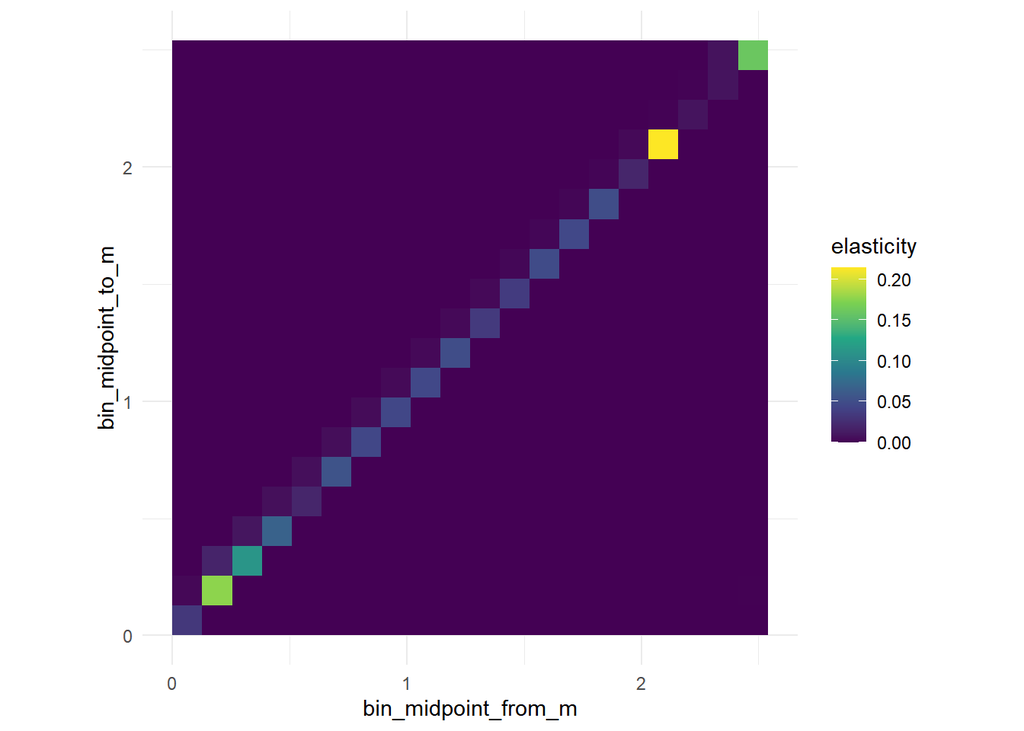

```r
sens_elas_plot_full.df %>%
  group_by(size_to, size_from, bin_midpoint_to_m, bin_midpoint_from_m) %>%
  summarise(sensitivity = median(sensitivity, na.rm = TRUE),
            elasticity = median(elasticity, na.rm = TRUE)) %>%
  ungroup() %>%
  ggplot(aes(x = bin_midpoint_from_m,
             y = bin_midpoint_to_m,
             fill = elasticity))+
  geom_tile()+
  coord_fixed()+
  theme_minimal()+
  scale_fill_viridis_c()
```

Again the jitteryness is caused by the small variations in the relation of mean size to bin midpoint. I’m surprised these had such a large effect. This seems to point towards needing to do a midpoint-rule IPM.

Normal for trees would be something like the Merow figure, with the most important transitions being within-class transition especially of the larger size classes.

# Hypothetical plots, full size range

## Build transition matrices

```r
hypothetical_plots =
  data.frame(intercept = rep(1, times = 9),
             fire = c(FALSE, TRUE, FALSE, FALSE, FALSE, FALSE, FALSE, FALSE, FALSE),
             wpbr = c(FALSE, FALSE, T, F, F, F, F, F, F),
             ba_scaled = c(0, 0, 0, -1, 1, 0, 0, 0, 0),
             cwd_dep90_scaled = c(0, 0, 0, 0, 0, -1, 1, 0, 0),
             cwd_mean_scaled = c(0, 0, 0, 0, 0, 0, 0, -1, 1),
             subp_id = 1:9,
             name = c('Undisturbed', 'Fire', 'WPBR', 'Low BA', 'High BA',
                      'Low Drought', 'High Drought', 'Wet Site', 'Dry Site'))
```

```r
A_hypotheticals_full =
  array(dim = c(nrow(size_metadata), # sizeclass to
                nrow(size_metadata), # sizeclass from
                nrow(hypothetical_plots), # plots
                nrow(posterior)), # posterior draws
        dimnames = list('class_to' = 1:nrow(size_metadata),
                        'class_from' = 1:nrow(size_metadata),
                        'plot' = 1:nrow(hypothetical_plots),
                        'draw' = 1:nrow(posterior)),
        data =
          sapply(X = 1:nrow(posterior),
                 FUN = function(draw){

                   # get beta_s for the current draw
                   beta_s =
                     posterior %>%
                     select(contains('beta_s')) %>%
                     slice(draw) %>%
                     as.data.frame() %>%
                     as.numeric()

                   beta_g =
                     posterior %>%
                     select(contains('beta_g')) %>%
                     slice(draw) %>%
                     as.data.frame() %>%
                     as.numeric()

                   beta_f =
                     posterior %>%
                     select(contains('beta_f')) %>%
                     slice(draw) %>%
                     as.data.frame() %>%
                     as.numeric()

                   sigmaEpsilon_g =
                     posterior %>%
                     slice(draw) %>%
                     pull(sigmaEpsilon_g) %>%
                     as.numeric()

                   sapply(X = 1:nrow(hypothetical_plots),
                          FUN = function(plot){

                            # construct explanatory variable matrix for survival
                            # for the current plot
                            X =
                              hypothetical_plots %>%
                              slice(plot) %>%
                              expand(nesting(intercept, fire, wpbr, ba_scaled,
                                             cwd_dep90_scaled,cwd_mean_scaled),
                                     dbh = size_metadata$dbh_m.mean) %>%
                              mutate(dbh_fire = dbh*fire,
                                     dbh_wpbr = dbh*wpbr,
                                     dbh_ba = dbh*ba_scaled,
                                     dbh_cwd_dep90 = dbh*cwd_dep90_scaled,
                                     dbh_cwd_mean = dbh*cwd_mean_scaled) %>%
                              select(intercept, dbh, fire, wpbr, ba_scaled,
                                     cwd_dep90_scaled, cwd_mean_scaled,
                                     dbh_fire, dbh_wpbr, dbh_ba,
                                     dbh_cwd_dep90, dbh_cwd_mean) %>%
                              as.matrix()

                            # calculate size_from length vector of survival
                            # probabilities on this plot with this parameter draw
                            p = boot::inv.logit(as.numeric(X %*% beta_s))

                            mu = as.numeric(X %*% beta_g)

                            f = exp(as.numeric(X %*% beta_f))

                            sapply(X = 1:nrow(size_metadata),
                                   FUN = function(class_from){

                                     g =
                                       ((pnorm(size_metadata$bin_upper,
                                               mu[class_from],
                                               sigmaEpsilon_g) -
                                           pnorm(size_metadata$bin_lower,
                                                 mu[class_from],
                                                 sigmaEpsilon_g))/
                                          (1-pnorm(0,
                                                mu[class_from],
                                                sigmaEpsilon_g)))

                                     sapply(X = 1:nrow(size_metadata),
                                            FUN = function(class_to){

                                              transition_prob =
                                                # survival of each from class
                                                (p[class_from] *
                                                # prob of growth from to
                                                g[class_to]) +
                                                # number of new recruits
                                                (f[class_from] *
                                                 size_metadata$r[class_to])
                                              return(transition_prob)

                                              # for testing
                                              #paste0('d:',draw,'|s:',plot,
                                              #  '|f:',class_from,'|t:',class_to)
                                            })
                                   })
                            })
                 }))


saveRDS(A_hypotheticals_full,
        here::here('02-data',
                   '03-results',
                   'real_fits',
                   'hypothetical_As_full.rds'))
```

```r
A_hypotheticals_full =
  readRDS(here::here('02-data',
                     '03-results',
                     'real_fits',
                     'hypothetical_As_full.rds'))
```

## Asymptotic population growth rate

```r
#### hypothetical lambda #######################################################

hypothetical_lambdas_full.matrix =
  matrix(nrow = nrow(hypothetical_plots),
         ncol = 4000,
         data =
           sapply(X = 1:nrow(hypothetical_plots),
                  FUN = function(plot){
                    sapply(X = 1:4000,
                           FUN = function(draw){
                             max(Re(eigen(A_hypotheticals_full[,,plot,draw])$values))
                           })
                  }))

hypothetical_lambdas_full =
  hypothetical_plots %>%
  expand(nesting(subp_id, name, intercept, fire, wpbr, ba_scaled,
                 cwd_dep90_scaled, cwd_mean_scaled),
         data.frame(draw = 1:4000))


hypothetical_lambdas_full$lambda =
  sapply(X = 1:nrow(hypothetical_plots),
         FUN = function(plot){
           sapply(X = 1:4000,
                  FUN = function(draw){
                    # paste0('s:',plot,'d:',draw) for testing
                    max(as.numeric(Re(eigen(A_hypotheticals_full[,,plot,draw])$values)))
                  })
         }) %>%
  as.numeric()


pretty_names =
  hypothetical_plots$name
names(pretty_names) = hypothetical_plots$subp_id
```

This is figure 6 from the paper:

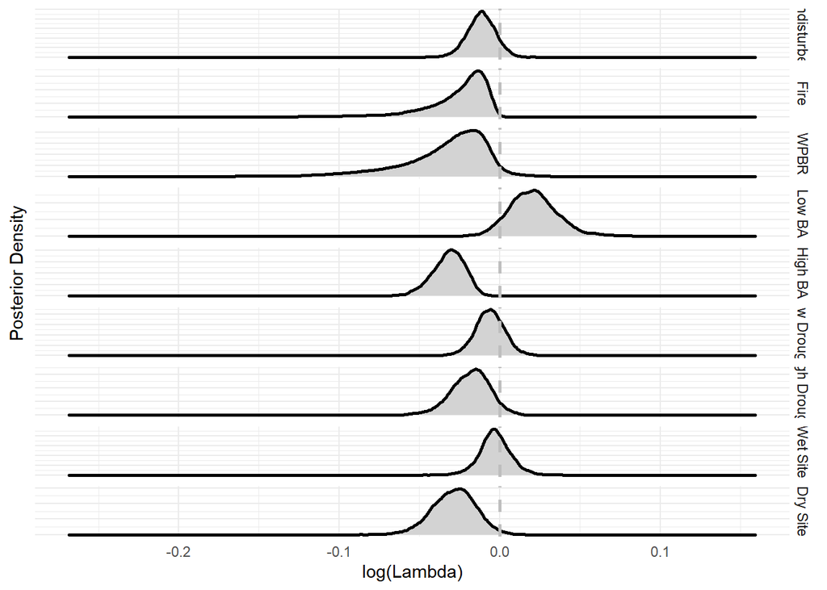

```r
ggplot(data =
           hypothetical_lambdas_full,
         aes(x = log(lambda)))+
  geom_density(lwd = 1, fill = 'lightgrey')+
  geom_vline(xintercept = 0, color = 'grey', lty = 2, lwd = 1)+
  theme_minimal()+
  facet_grid(subp_id~., scales = 'free_y',
             labeller = labeller(subp_id = pretty_names))+
  #scale_x_continuous(limits = c(0.95,1.05))+
  #coord_cartesian(xlim = c(0.9, 1.1))+
  theme(axis.text.y = element_blank())+
  labs(x = 'log(Lambda)', y = 'Posterior Density')
```

```r
hypothetical_lambda_summary =
  hypothetical_lambdas_full %>%
  group_by(subp_id, name) %>%
  summarise(lambda.med = median(lambda),
            lambda.05 = quantile(lambda, probs = 0.05),
            lambda.95 = quantile(lambda, probs = 0.95))
```

## Stable size distribution

```r
hypothetical_ssd_full =
  array(dim = c(nrow(size_metadata),
                nrow(hypothetical_plots),
                4000),
        dimnames =
          list('sizeclass' = 1:nrow(size_metadata),
               'plot' = 1:nrow(hypothetical_plots),
               'draw' = 1:4000),
        data =
          sapply(X = 1:4000,
                 FUN = function(draw){
                   sapply(X = 1:nrow(hypothetical_plots),
                          FUN = function(plot){
                            A = A_hypotheticals_full[,,plot,draw]
                            w.eigen = Re(eigen(A)$vectors[,1])
                            ssd = w.eigen / sum(w.eigen)
                            return(ssd)
                          })
                 }))


hypothetical_ssd_full.df =
  hypothetical_plots %>%
  expand(nesting(intercept, fire, wpbr, ba_scaled, cwd_dep90_scaled,
                 cwd_mean_scaled, subp_id, name),
         sizeclass = 1:nrow(size_metadata),
         draw = 1:4000) %>%
  left_join(size_metadata %>%
              mutate(bin_midpoint_cm = bin_midpoint*100) %>%
              select(sizeclass = bin_id, bin_midpoint_cm)) %>%
  arrange(subp_id, sizeclass, draw)

hypothetical_ssd_full.df$class_proportion =

  as.numeric(
    sapply(X = 1:nrow(hypothetical_plots),
           FUN = function(plot){

             as.numeric(
               sapply(X = 1:nrow(size_metadata),
                      FUN = function(sizeclass){

                        return(hypothetical_ssd_full[sizeclass,plot,])
                      })
             )

           }))
```

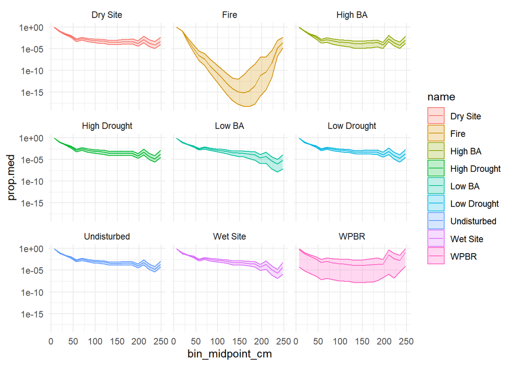

```r
# Fire makes the SSD really for the very rare bigger size classes, fewer
# mid-to-large trees and more superlarge
hypothetical_ssd_full.df %>%
  group_by(bin_midpoint_cm, sizeclass, name, subp_id) %>%
  summarise(prop.med = median(class_proportion),
            prop.05 = quantile(class_proportion, 0.05),
            prop.95 = quantile(class_proportion, 0.95)) %>%
  ungroup() %>%
  ggplot(aes(x = bin_midpoint_cm, color = name, fill = name))+
  #geom_point(aes(y = prop.med), size = 1)+
  geom_line(aes(y = prop.med))+
  geom_ribbon(aes(ymin = prop.05, ymax = prop.95), alpha = 0.25)+
  theme_minimal()+
  scale_y_log10()+
  facet_wrap(~name)
```

This looks pretty reasonable to me.

## Reproductive value

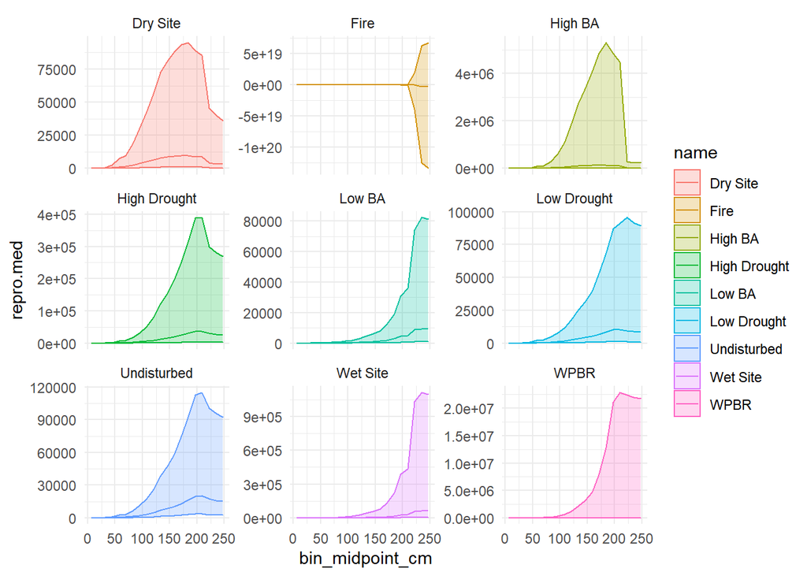

```r
hypothetical_repro_full =
  array(dim = c(nrow(size_metadata),
                nrow(hypothetical_plots),
                4000),
        dimnames =
          list('sizeclass' = 1:nrow(size_metadata),
               'plot' = 1:nrow(hypothetical_plots),
               'draw' = 1:4000),
        data =
          sapply(X = 1:4000,
                 FUN = function(draw){
                   sapply(X = 1:nrow(hypothetical_plots),
                          FUN = function(plot){
                            A = A_hypotheticals_full[,,plot,draw]
                            v.eigen = Re(eigen(t(A))$vectors[,1])
                            rv = v.eigen / v.eigen[1]
                            return(rv)
                          })
                 }))


hypothetical_repro_full.df =
  hypothetical_plots %>%
  expand(nesting(intercept, fire, wpbr, ba_scaled, cwd_dep90_scaled,
                 cwd_mean_scaled, subp_id, name),
         sizeclass = 1:nrow(size_metadata),
         draw = 1:4000) %>%
  left_join(size_metadata %>%
              mutate(bin_midpoint_cm = bin_midpoint*100) %>%
              select(sizeclass = bin_id, bin_midpoint_cm)) %>%
  arrange(subp_id, sizeclass, draw)

hypothetical_repro_full.df$repro =

  as.numeric(
    sapply(X = 1:nrow(hypothetical_plots),
           FUN = function(plot){

             as.numeric(
               sapply(X = 1:nrow(size_metadata),
                      FUN = function(sizeclass){

                        return(hypothetical_repro_full[sizeclass,plot,])
                      })
             )

           }))

# Again these reproductive values are wonky, esp for burned plots. Something
# about the transition matrix for burned plots is weird.
hypothetical_repro_full.df %>%
  group_by(bin_midpoint_cm, sizeclass, name, subp_id) %>%
  #filter(subp_id != 2) %>%
  summarise(repro.med = median(repro),
            repro.05 = quantile(repro, 0.05, na.rm = TRUE),
            repro.95 = quantile(repro, 0.95, na.rm = TRUE)) %>%
  ungroup() %>%
  ggplot(aes(x = bin_midpoint_cm, color = name, fill = name))+
  #geom_point(aes(y = prop.med), size = 1)+
  geom_line(aes(y = repro.med))+
  geom_ribbon(aes(ymin = repro.05, ymax = repro.95), alpha = 0.25)+
  theme_minimal()+
  facet_wrap(~name, scales = 'free_y')
```

Not sure what’s going on with fire, where sometimes the biggest size classes have strongly negative reproductive values. Both fire and WPBR have some crazy high reproductive values for the largest stems. Some sort of overflow/underflow error? Note that it’s only in the biggest size classes - this is what made me start to think about the exponential transform in the fecundity function and whether that’s realistic for the biggest size classes.

## Sensitivity and elasticity

```r
# sensitivity and elasticity
hypothetical_vdotw_full =
  matrix(nrow = nrow(hypothetical_plots),
         ncol = 4000,
         data =
           sapply(X = 1:nrow(hypothetical_plots),
                  FUN = function(plot){
                    sapply(X = 1:4000,
                           FUN = function(draw){
                             sum(hypothetical_ssd_full[,plot,draw] *
                                   hypothetical_repro_full[,plot,draw])*0.127
                           })
                  }))


hypothetical_sens_full =
  array(dim = list(nrow(size_metadata),
                   nrow(size_metadata),
                   nrow(hypothetical_plots),
                   4000),
        dimnames =
          list('size_to' = 1:nrow(size_metadata),
               'size_from' = 1:nrow(size_metadata),
               'plot' = 1:nrow(hypothetical_plots),
               'draw' = 1:4000),
        data =

          sapply(X = 1:4000,
                 FUN = function(draw){
                   sapply(X = 1:nrow(hypothetical_plots),
                          FUN = function(plot){
                            outer(hypothetical_repro_full[,plot,draw],
                                  hypothetical_ssd_full[,plot,draw])/
                              hypothetical_vdotw_full[plot,draw]
                          })
                 })
  )

hypothetical_elas_full =
  array(dim = list(nrow(size_metadata),
                   nrow(size_metadata),
                   nrow(hypothetical_plots),
                   4000),
        dimnames =
          list('size_to' = 1:nrow(size_metadata),
               'size_from' = 1:nrow(size_metadata),
               'plot' = 1:nrow(hypothetical_plots),
               'draw' = 1:4000),
        data =

          sapply(X = 1:4000,
                 FUN = function(draw){
                   sapply(X = 1:nrow(hypothetical_plots),
                          FUN = function(plot){

                            matrix(as.vector(hypothetical_sens_full[,,plot,draw])*
                                     as.vector(A_hypotheticals_full[,,plot,draw])/
                                     hypothetical_lambdas_full.matrix[plot,draw])


                          })
                 })
  )



hypothetical_sens_elas_full.df  =
  expand.grid(size_to = size_metadata$bin_id,
              size_from = size_metadata$bin_id) %>%
  left_join(size_metadata %>%
              select(size_to = bin_id,
                     bin_midpoint_to_m = bin_midpoint)) %>%
  left_join(size_metadata %>%
              select(size_from = bin_id,
                     bin_midpoint_from_m = bin_midpoint)) %>%
  expand(nesting(size_to, size_from, bin_midpoint_to_m, bin_midpoint_from_m),
         subp_id = 1:9,
         draw = 1:4000) %>%
  arrange(subp_id, size_to, size_from, draw)


hypothetical_sens_elas_full.df$sensitivity =
  sapply(X = 1:nrow(hypothetical_plots),
         FUN = function(plot){
           sapply(X = 1:nrow(size_metadata),
                  FUN = function(size_to){

                    sapply(X = 1:nrow(size_metadata),
                           FUN = function(size_from){
                             hypothetical_sens_full[size_to, size_from, plot,]
                           })
                  })
         }) %>%
  as.vector()


hypothetical_sens_elas_full.df$elasticity =
  sapply(X = 1:nrow(hypothetical_plots),
         FUN = function(plot){
           sapply(X = 1:nrow(size_metadata),
                  FUN = function(size_to){

                    sapply(X = 1:nrow(size_metadata),
                           FUN = function(size_from){
                             hypothetical_elas_full[size_to, size_from, plot,]
                           })
                  })
         }) %>%
  as.vector()
```

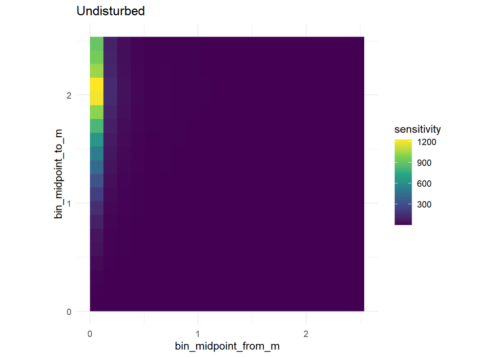

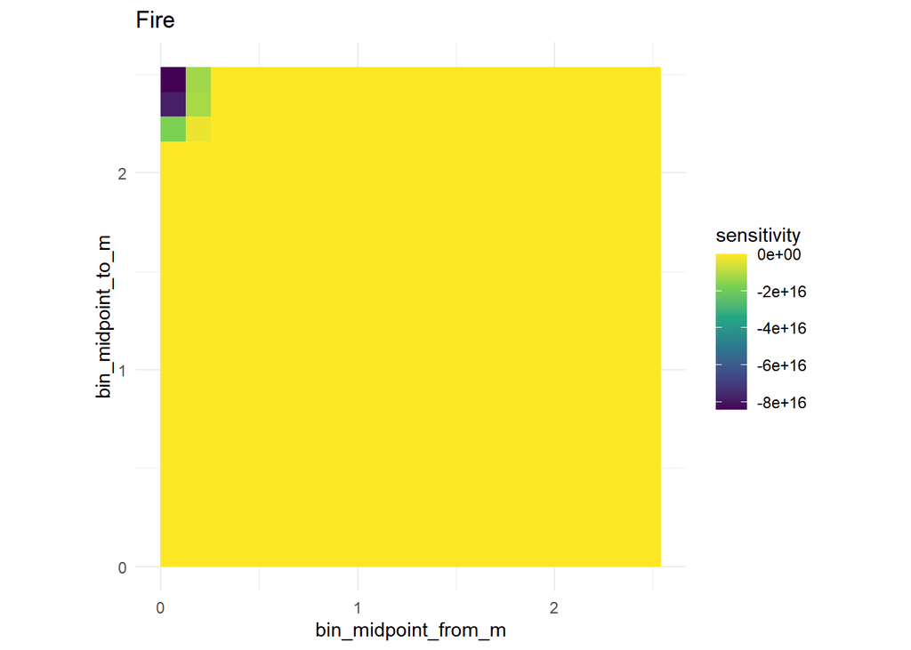

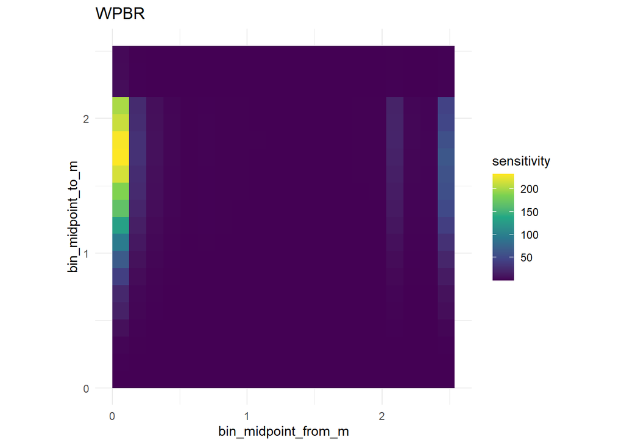

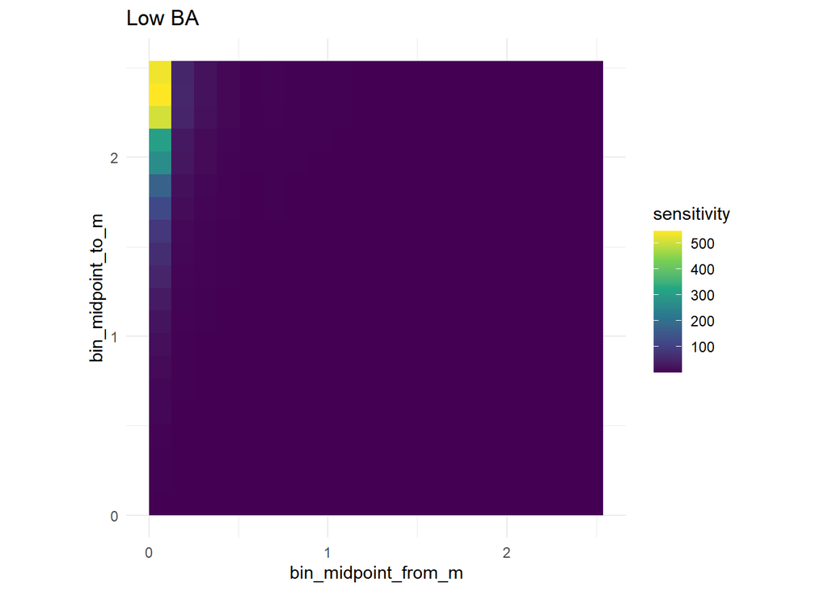

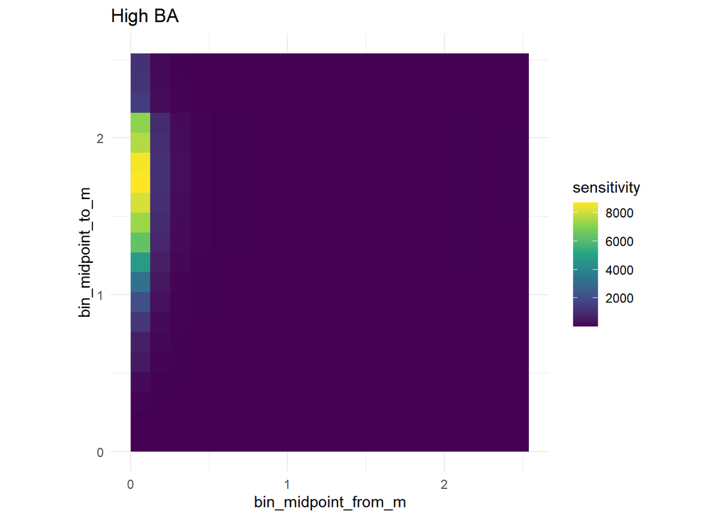

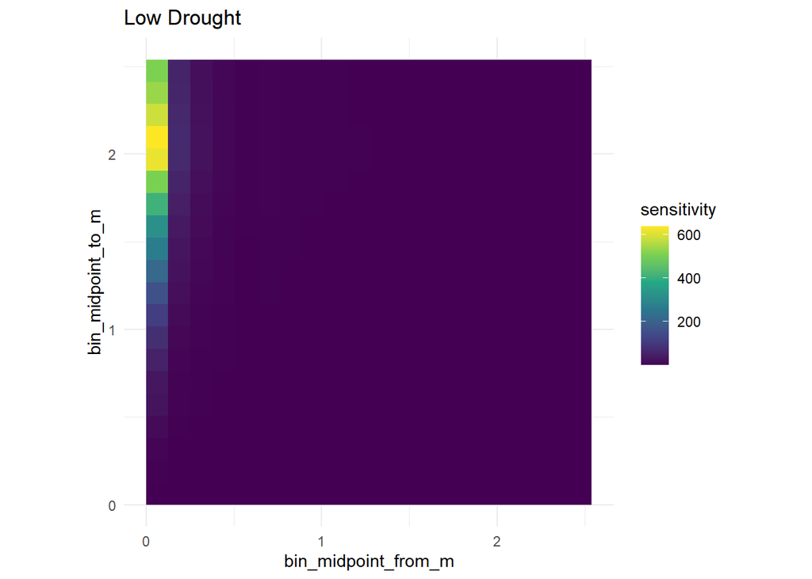

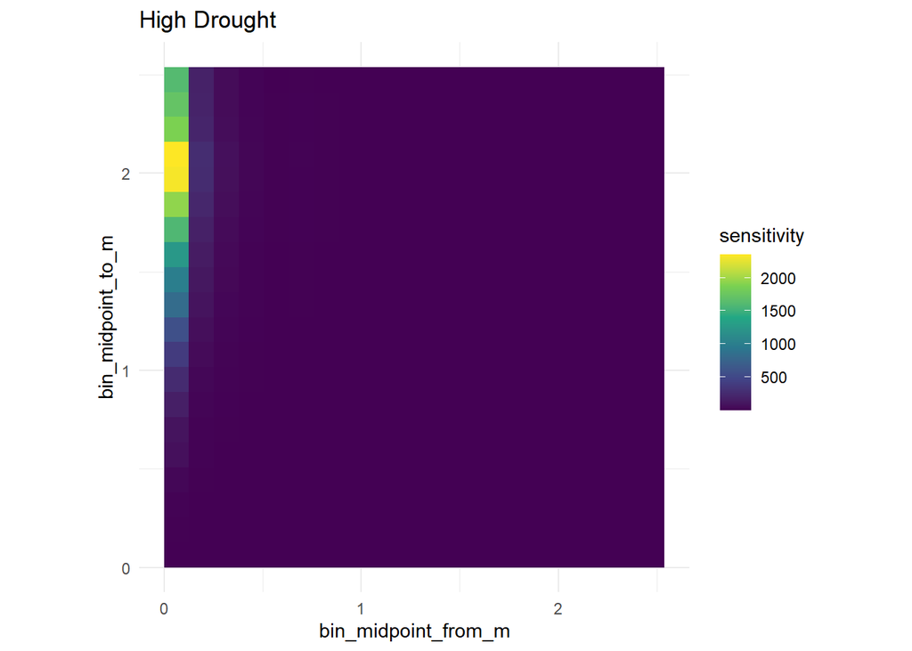

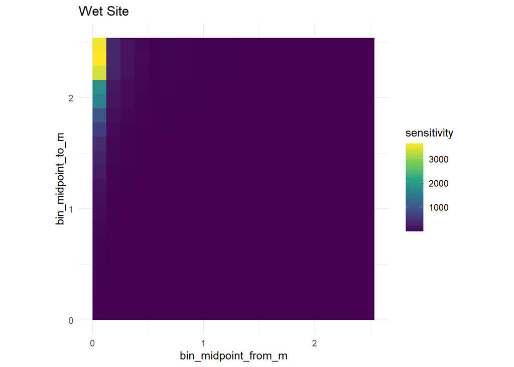

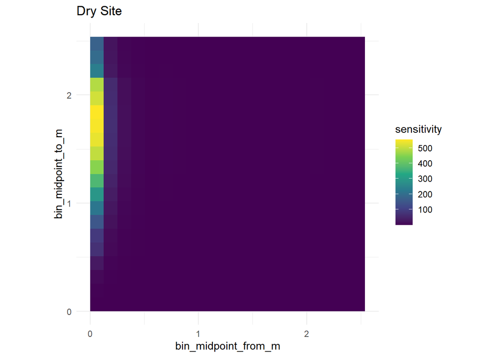

```r
sensitivity_plots =
  lapply(X = 1:9,
         FUN = function(s){

              hypothetical_sens_elas_full.df %>%
              group_by(size_to, size_from, bin_midpoint_to_m, bin_midpoint_from_m,
                       subp_id) %>%
              summarise(sensitivity = median(sensitivity, na.rm = TRUE),
                        elasticity = median(elasticity, na.rm = TRUE)) %>%
              ungroup() %>%
              left_join(hypothetical_plots %>%
                          select(subp_id, name)) %>%
              filter(subp_id==s) %>%
              ggplot(aes(x = bin_midpoint_from_m,
                         y = bin_midpoint_to_m,
                         fill = sensitivity))+
              geom_tile()+
              coord_fixed()+
              theme_minimal()+
              scale_fill_viridis_c()+
                labs(title = hypothetical_plots$name[s])
         })

sensitivity_plots
```

This is the Here’s where things are getting really weird. I have strongly negative numbers for sensitivity for Fire? That’s not right. And these are the median sensitivities across all of the IPMs generated from different posterior draws, so it’s not just the edge case behavior here that’s weird, it’s the central tendency.